# Trabalho 2

Rodrigo Malta Esteves

10/03/2021

1. a)
2. b)
3. c)
4. d)
5. e)

```r
library(readr)
library(dplyr)
```

```r
atend <- read.csv("C:\\Users\\malta\\Desktop\\Pós Graduação\\Introdução ao Aprendizado Estatístico\\Trabalho 2\\Rodrigo Esteves - atendimentos.csv")
```

Como descrito na introdução, temos que $X1$ é a variável aleatória do número de clientes atendidos por hora e $\theta$ é a média do número de clientes atendidos. Essas variáveis seguem as distribuições de probabilidade: $X1\sim Poisson(\theta)$ e $\theta \sim Gamma(\alpha,\lambda)$. Além disso, temos $n=100$ registros de contagem de atendimentos.

## a)

Assumimos uma $\textit{priori 1}$ em que nosso parâmetro $\theta \sim Gamma(0.001,0.001)$.

Calculando as médidas de variância, desvio padrão e média desse parâmetro, podemos observar que as medidas de dispersão são muito maiores que a média. Logo, é possível afirmar que, nesse caso, $\theta$ tem uma distribuição vaga a priori.

```r
#priori 1
theta1 <- rgamma(100000,.001,.001)
theta1 <- as.data.frame(theta1)
theta1 %>%
  summarize(MediaPriori = mean(theta1),
            VarianciaPriori = var(theta1),
            DesvioPriori = sd(theta1))
```

```
##   MediaPriori VarianciaPriori DesvioPriori
## 1    1.020012        1084.089     32.92551
```

## b)

O analista informa que a média de atendimento gira em torno de 5 por hora. Como temos que o parâmetro $\theta$ tem distribuição $gama$, sabemos que $E[\theta]=\frac{\alpha}{\lambda}$. Logo, podemos descrever uma relação entre os parâmetro: $\frac{\alpha}{\lambda} = 5 \implies \alpha = 5\lambda$. Também é informado que a $Prob(\theta > 10)\approx5\%$.

Associando essas duas informações é possível encontrar uma aproximação para os parâmetro da $\textit{priori 2}$. Para isso, criamos uma grade de valores de 0 até 5 para $\lambda$, uma variável $\alpha$, respeitando a relação descrita anteriormente, e geramos uma matriz com as probabilidades associadas às distribuições $gama$ com esses parâmetros.

Observamos que os parâmetros que mais se aproximam dos $5\%$ de probabilidade são $\alpha = 3.5$ e $\lambda = 0.7$.

```r
#Elicitação dos par^ametros da priori 2
lambda<-seq(0,5,0.1)
alpha<-5*lambda
matriz<-cbind(alpha,lambda,1-pgamma(10,shape=alpha,rate=lambda))
matriz #alpha = 3.5 e lambda = 0.7
```

```
##       alpha lambda
##  [1,]   0.0    0.0 1.000000e+00
##  [2,]   0.5    0.1 1.572992e-01
##  [3,]   1.0    0.2 1.353353e-01
##  [4,]   1.5    0.3 1.116102e-01
##  [5,]   2.0    0.4 9.157819e-02
##  [6,]   2.5    0.5 7.523525e-02
##  [7,]   3.0    0.6 6.196880e-02
##  [8,]   3.5    0.7 5.118135e-02
##  [9,]   4.0    0.8 4.238011e-02
## [10,]   4.5    0.9 3.517354e-02
## [11,]   5.0    1.0 2.925269e-02
## [12,]   5.5    1.1 2.437324e-02
## [13,]   6.0    1.2 2.034103e-02
## [14,]   6.5    1.3 1.700084e-02
```

[output cut: 37 more lines]

## c)

Comparando as distribuições das duas prioris, podemos ver claramente como a distribuição a $\textit{priori 1}$ reflete uma falta de conhecimento sobre o parâmetro ao ter quase todos os seus valores próximos ao zero para toda grade de valores de $\theta$. Já a $\textit{priori 2}$ explica muito mais sobre o parâmetro, uma vez que atribui probabilidades de forma mais heterogênea entre os valores de $\theta$.

```r
#Esperança e Variância da Priori 2
#Teórico
MediaTeoPriori2 <- 3.5/.7 #média teórica
VarianciaTeoPriori2 <- 3.5/(.7^2) #variância teórica

#Amostral
theta2 <-rgamma(100000,3.5,0.7)
theta2 <- as.data.frame(theta2)
theta2 %>%
  summarize(MediaPriori2 = mean(theta2),
            VarianciaPriori2 = var(theta2),
            MediaTeoPriori2,
            VarianciaTeoPriori2)
```

```
##   MediaPriori2 VarianciaPriori2 MediaTeoPriori2 VarianciaTeoPriori2
## 1     4.993909         7.196995               5            7.142857
```

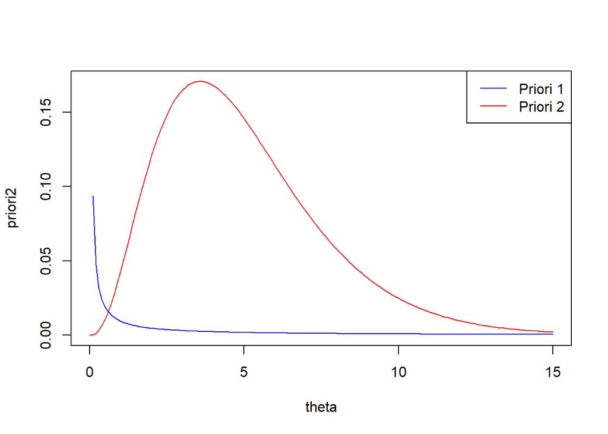

```r
#Gráfico das prioris para uma grade de valores de theta entre 0 e 15
theta<-seq(0,15,0.1)
priori1<-dgamma(theta,shape=0.01, rate=0.01)
priori2<-dgamma(theta,shape=3.5, rate=0.7)
plot(theta, priori2,t="l",col="red") #Priori 2 muito mais informativa
lines(theta, priori1,col="blue")
legend("topright",legend=c("Priori 1","Priori 2"),lty=c(1,1),col=c(4,2))
```

## d)

Função de verossimilhança para uma Poisson:

$l(\theta; \underline{x1}) = \prod_{i=1}^{n} \frac{e^{-\theta}\theta^{(x1)_{i}}}{(x1)!} = \frac{e^{-n\theta}\theta^{\sum(x1)_{i}}}{\prod(x1_{i}!)}$.

Estimador de máxima verossimilhança para $\theta$:

$L(\theta;\underline{x1}) = log(l(\theta; X1)) = \sum(x1)_{i}log(\theta)-n\theta-log(\prod (x1)_{i})$.

$\frac{dL(\theta;\underline{x1})}{d\theta} = \frac{\sum(x1)_{i}}{\theta} - n = 0$.

$\hat{\theta} = \frac{\sum(x1)_{i}}{n}$

As distribuições apresentam um resultado esperado. A amostra grande tende a concentrar seus valores mais próximo da máxima verossímilhança, enquanto a amostra pequena apresenta uma dispersão maior.

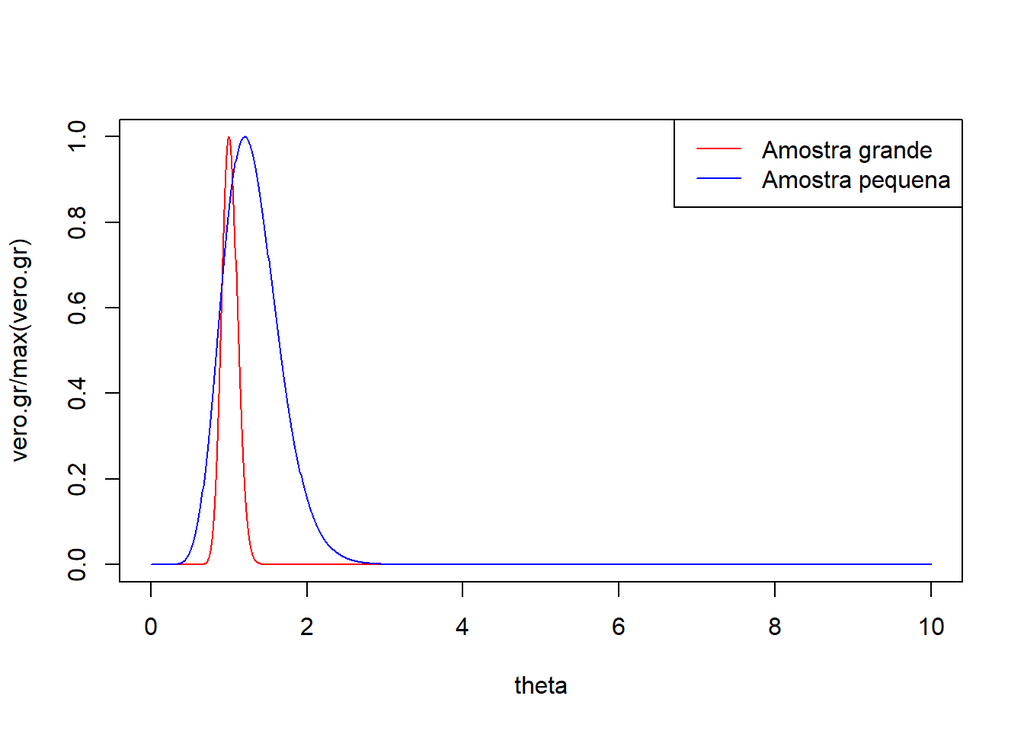

```r
#set.seed(1234)
#amostras
amostra.gr<- atend
amostra.pq<-sample(amostra.gr$X1,10)

#parâmetros
t1 <- sum(amostra.gr$X1)
n1 <- length(amostra.gr$X1)
t2 <- sum(amostra.pq)
n2 <- length(amostra.pq)

#estimadores de máxima verossimilhança
mv1 <- t1/n1
mv2 <- t2/n2

theta<-seq(0,10,0.01)
vero.gr<-exp(-n1*theta)*theta^t1
vero.pq<-exp(-n2*theta)*theta^t2
plot(theta,vero.gr/max(vero.gr),t="l",col="red")
lines(theta,vero.pq/max(vero.pq),col="blue")
legend("topright",legend=c("Amostra grande","Amostra pequena"),lty=c(1,1),col=c(2,4))
```

## e)

Sabemos que se $Y_{1},...,Y_{n}$ independentes e identicamente distribuidos seguem uma distribuição $Poisson(\theta)$ e $\theta\sim Gama(\alpha,\beta)$, então, a posteriori, temos que $\theta|\underline{y} \sim Gama(\alpha + \sum y_{i},\beta + n)$.

Observamos aqui 4 posterioris possíveis (consideramos $t1$ como o somatório dos valores da amostra grande, $t2$ como o somatório dos valores da amostra pequena,$n_{1}$ o tamanho da amostra grande e $n_{2}$ o tamanho da amostra pequena):

1. Para priori 1 e amostra pequena: $\theta|\underline{y} \sim Gama(0.001 + t2,0.001 + n_{2})$
2. Para priori 2 e amostra pequena: $\theta|\underline{y} \sim Gama(3.5 + t2,0.7 + n_{2})$
3. Para priori 1 e amostra grande: $\theta|\underline{y} \sim Gama(0.001 + t1,0.001 + n_{1})$
4. Para priori 2 e amostra grande: $\theta|\underline{y} \sim Gama(3.5 + t1,0.7 +n_{1})$

Podemos perceber que para as posterioris com a uma amostra grande a informação vinda dos dados, representada pela verossimilhança, dominará a distribuição. Essa característica fica bem clara dada a concentração de ambas as posterioris em torno do estimador de máxima verossimilhança.

Para as posterioris com uma amostra pequena, observamos uma dispersão maior para os valores de $\theta$. Percemos também que como a priori 1 é pouco informativa a sua posteriori será muito semelhante à distribuição dos dados, ou seja, a própria curva de verossimilhança. Já a segunda posteriori terá os seus valores levados um pouco mais para a direita, uma vez que a priori 2 é mais informativa e tem uma média maior.

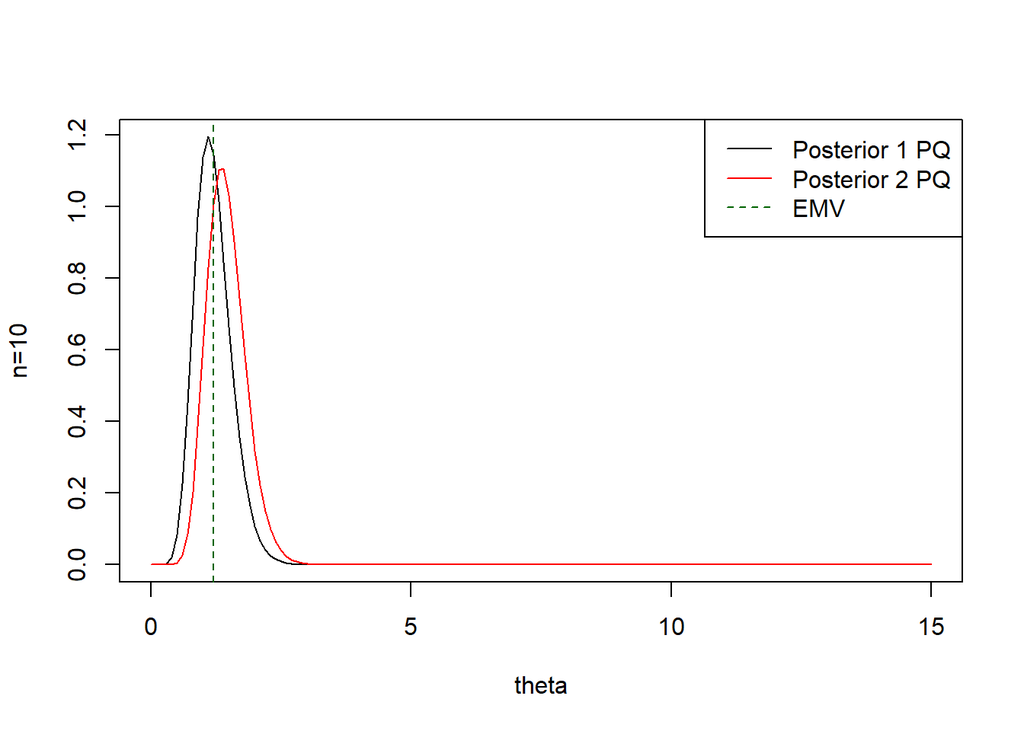

```r
theta<-seq(0,15,0.1)
poster.1.pq <- dgamma(theta,0.001+t2, 0.001+n2)
poster.2.pq <- dgamma(theta,3.5+t2, 0.7 + n2)
poster.1.gr <- dgamma(theta,0.001+t1, 0.001+n1)
poster.2.gr <- dgamma(theta,3.5+t1, 0.7 + n1)

##Preparação de uma janela gráfica particionada em duas linhas e duas colunas, para acomodar os 4 gráficos que
#par(mfrow=c(1,2))
#Posteriori para theta sob amostra pequena e priori 1:
plot(theta,poster.1.pq,type="l",ylab="n=10")
#Posteriori para theta sob amostra pequena e priori 2:
lines(theta,poster.2.pq,type="l",ylab="n=10",col=2)
abline(v=mv2,lty=2,col="darkgreen")
legend("topright",legend=c("Posterior 1 PQ","Posterior 2 PQ","EMV"),lty=c(1,1,2),col=c(1,2,"darkgreen"))
```

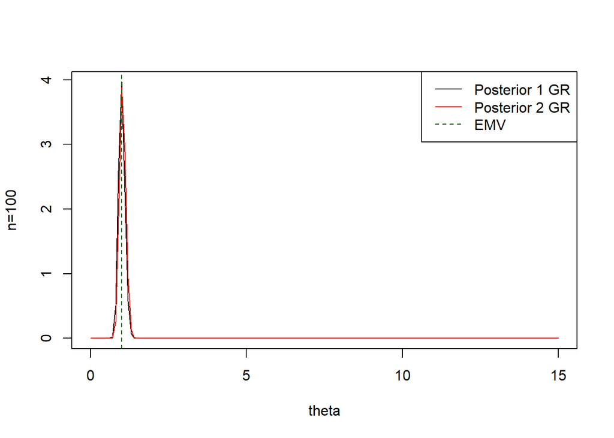

```r
#Posteriori para theta sob amostra grande e priori 1:
plot(theta,poster.1.gr,type="l",ylab="n=100")
#Posteriori para theta sob amostra grande e priori 2:
lines(theta,poster.2.gr,type="l",ylab="n=100",col=2)
abline(v=mv1,lty=2,col="darkgreen")
legend("topright",legend=c("Posterior 1 GR","Posterior 2 GR","EMV"),lty=c(1,1,2),col=c(1,2,"darkgreen"))
```